# Peer Assessment 2 - Storm Data Analysis

Deizu

Sunday, August 23rd, 2015

# Storm Data Analysis

## Synopsis

This is the 2nd peer analysis course project for the Coursera course Reproducible Research. The analysis takes raw data from NOAA and uses it to understand the estimated impact of major weather events on the population and economy in the US. 3 panel plots are included for reference.

## Data Processing

### Loading Data

The first step in processing our data is obtaining it.

```r
# Check for existence of data directory within working directory
if(!dir.exists("./data")){dir.create("./data/")}
# Check for existence of data, download if not present and notify when done
if(!file.exists("./data/StormData.csv.bz2")){
  fileurl <- "https://d396qusza40orc.cloudfront.net/repdata%2Fdata%2FStormData.csv.bz2"
  download.file(fileurl,destfile="./data/StormData.csv.bz2",mode='wb')
  rm(fileurl)
  message("Data is ready for loading!")
} else {
  message("Data already present and ready for loading!")
}
```

```
## Data already present and ready for loading!
```

We’ll load some libraries to help us achieve our goal.

```r
library(gsubfn) # For year extraction and replacement
library(dplyr) # For tbl_df() function, etc
library(knitr) # For the kable() function
library(lubridate) # For CPI calculation assistance
```

Now that we have the data, we can load it into R for processing.

```r
raw <- read.csv("./data/StormData.csv.bz2", header=TRUE)
```

### Working with columns

We need to work with the EVTYPE column, and it’s super messy. NOAA recognizes 48 event types, and this column contains 985 distinct event types. We’ll try to whittle down and combine these as logically as possible. Let’s start by getting our data into shape. We’ll only need the damage-related columns after the date and event type. We’ll simplify a bit by making the date into a year column.

```r
# Copy the raw data over for manipulation
data <- raw[,c(2,7:8,23:28)]
# Convert to character for strapplyc
data$BGN_DATE <- as.character(data$BGN_DATE)
# Replace the BGN_DATE column with an extracted YEAR column
data$BGN_DATE <- unlist(strapplyc(data$BGN_DATE,
                      "[[:digit:]]{1,2}\\/[[:digit:]]{1,2}\\/([[:digit:]]{4})"))
names(data)[1] <- c("YEAR")
# Convert YEAR column back to factor variable
data$YEAR <- as.factor(data$YEAR)


# Make the data a tbl for easier summarization
data <- tbl_df(data)
```

Ok, now we’ll want to make sure we have a list we can validate against. NOAA provides its guidelines in a publication called the “NATIONAL WEATHER SERVICE INSTRUCTION 10-1605.” You can access a PDF copy [here](https://d396qusza40orc.cloudfront.net/repdata%2Fpeer2_doc%2Fpd01016005curr.pdf). Table 2.1.1 (Storm Data Event Table) on page 6 is replicated in R code below.

```r
# Create frequency table of each messy EVTYPE
cleanme <- as.data.frame(table(toupper(data$EVTYPE)))

# Generate list of 48 official EVTYPEs based on NOAA documentation
noaa_evtypes <- structure(
  list(
    EventName = structure(
      c(1L, 2L, 3L, 4L, 5L, 6L, 7L, 8L, 9L, 10L, 11L, 12L, 13L, 14L, 15L, 17L,
        18L, 16L, 19L, 20L, 21L, 22L, 23L, 24L, 25L, 26L, 27L, 28L, 29L, 30L,
        31L, 32L, 33L, 34L, 35L, 36L, 37L, 38L, 39L, 40L, 41L, 42L, 43L, 44L,
        45L, 46L, 47L, 48L),
      .Label = c("Astronomical Low Tide", "Avalanche", "Blizzard",
                 "Coastal Flood", "Cold/Wind Chill", "Debris Flow",
                 "Dense Fog", "Dense Smoke", "Drought", "Dust Devil",
                 "Dust Storm", "Excessive Heat", "Extreme Cold/Wind Chill",
                 "Flash Flood", "Flood", "Freezing Fog", "Frost/Freeze",
                 "Funnel Cloud", "Hail", "Heat", "Heavy Rain", "Heavy Snow",
                 "High Surf", "High Wind", "Hurricane (Typhoon)", "Ice Storm",
                 "Lake-Effect Snow", "Lakeshore Flood", "Lightning",
                 "Marine Hail", "Marine High Wind", "Marine Strong Wind",
                 "Marine Thunderstorm Wind", "Rip Current", "Seiche", "Sleet",
                 "Storm Surge/Tide", "Strong Wind", "Thunderstorm Wind",
                 "Tornado", "Tropical Depression", "Tropical Storm", "Tsunami",
                 "Volcanic Ash", "Waterspout", "Wildfire", "Winter Storm",
                 "Winter Weather"),
      class = "factor"),
    Designator = structure(
      c(3L, 3L, 3L, 3L, 3L, 1L, 3L, 3L, 3L, 1L, 3L, 3L, 3L, 1L, 1L, 3L, 1L, 3L,
        1L, 3L, 1L, 3L, 3L, 3L, 3L, 3L, 3L, 3L, 1L, 2L, 2L, 2L, 2L, 3L, 3L, 3L,
        3L, 3L, 1L, 1L, 3L, 3L, 3L, 3L, 2L, 3L, 3L, 3L),
      .Label = c("C", "M", "Z"),
      class = "factor")
    ),
  .Names = c("EventName", "Designator"),
  class = "data.frame",
  row.names = c(NA, -48L)
  )
```

We’ll want to see how our transformations change the data, so we’ll begin by making the EVTYPE column a character class and set some initial counts down.

```r
# 0. Set up for cleaning
     # Cleaning stat tracking
     counts <- data.frame("Step"=character(0),"Unique"=numeric(0),"Total Observations"=numeric(0))
     all <- unique(data$EVTYPE)
     counts <- rbind(c("Raw Data Counts",length(all),nrow(data)))

     # Force upper case characters
     data$EVTYPE <- toupper(as.character(data$EVTYPE))

     # Cleaning stat tracking
     all <- unique(data$EVTYPE)
     counts <- rbind(counts,c("Force Upper Case",length(all),nrow(data)))
```

We can remove any kind of summary or aggregate information from the dataset since it’s not specific enough for our purposes.

```r
# 1. Exclude summary and monthly aggregate types
     data[grep("summary|month|\\?|other|county", data$EVTYPE, ignore.case =
                 TRUE, value = FALSE),"EVTYPE"] <- "SUMMARY"
     data <- filter(data, EVTYPE!="SUMMARY")

     # Cleaning stat tracking
     all <- unique(data$EVTYPE)
     counts <- rbind(counts,c("Drop Summaries and Aggregates",length(all),
                              nrow(data)))
```

We can also remove any sort of comparison word which might complicate consolidation. We’re not removing the observations, just the words and extraneous spaces from the EVTYPE column. (We’re also merging “marine” weather event types into their parent types.)

```r
# 2. Remove comparison words
     data$EVTYPE <- gsub("abnormally|abnormal|bitter|early|late|extended|marine|
                      minor|normal|prolonged|record|unseasonably|unseasonal|
                      unusual|unusually|urban|very|and", "", ignore.case = T,
                      data$EVTYPE)
     data$EVTYPE <- gsub("^\\s+|\\s+$","", data$EVTYPE, ignore.case = T)
     data$EVTYPE <- gsub("^\\/+","", data$EVTYPE, ignore.case = T)
     data$EVTYPE <- gsub("^\\s+|\\s+$","", data$EVTYPE, ignore.case = T)
     all <- unique(data$EVTYPE)
     counts <- rbind(counts,c("Strip Comparative Terms",length(all),nrow(data)))
```

Similarly, we can go ahead and ditch any non-weather words. Many of these relate to geographic features or causes of death or injury (without citing a specific weather event). We’ll remove these from our dataset.

```r
# 3. Remove non-weather words
     data[grep("accident|drowning|dam break|dam failure|^excessive$|exposure|
               |mishap|metro|flag|southeast|remnants|slump|none|northern|
               |no severe weather|mild pattern|^high$|^low$|^temperature[s]*$",
               data$EVTYPE, ignore.case = TRUE, value = FALSE),"EVTYPE"] <- ""
     data <- filter(data, EVTYPE!="")

     # Cleaning stat tracking
     all <- unique(data$EVTYPE)
     counts <- rbind(counts,c("Strip Non-Weather Terms",length(all),nrow(data)))
```

The majority of our work will be a *good faith* (READ: NON-EXPERT / LAYMAN / AMATEUR) attempt at placing the remaining unofficial EVTYPEs into an official bucket based on string matching and replacement. Referencing the guide linked above greatly aids the decision making process for how to recode these events.

```r
# 4. Cleaning with a series of regular expressions
     data[grep("hurr|typh", data$EVTYPE, ignore.case = TRUE, value = FALSE),"EVTYPE"
       ] <- "HURRICANE (TYPHOON)"
     data[grep("storm surge|high tide|blow-out|blowout|wave", data$EVTYPE,
            ignore.case = TRUE, value = FALSE),"EVTYPE"] <- "STORM SURGE/TIDE"
     data[grep("^[^w]*torn[^w]*$", data$EVTYPE, ignore.case = TRUE, value = FALSE),
       "EVTYPE"] <- "TORNADO"
     data[grep("dust", data$EVTYPE, ignore.case = TRUE, value = FALSE),"EVTYPE"
       ] <- "DUST STORM"
     data[grep("lightn|lighting|ligntning", data$EVTYPE, ignore.case = TRUE,
            value = FALSE),"EVTYPE"] <- "LIGHTNING"
     data[grep("thunder|tstorm|tstm|thundeer|tunderstorm|thunerstorm|thundestorm|
            thuderstorm", data$EVTYPE, ignore.case = TRUE, value = FALSE),"EVTYPE"
       ] <- "THUNDERSTORM WIND"
     data[grep("hail", data$EVTYPE, ignore.case = TRUE, value = FALSE),"EVTYPE"
       ] <- "HAIL"
     data[grep("smoke", data$EVTYPE, ignore.case = TRUE, value = FALSE),"EVTYPE"
       ] <- "DENSE SMOKE"
     data[grep("drought", data$EVTYPE, ignore.case = TRUE, value = FALSE),"EVTYPE"
       ] <- "DROUGHT"

     data[grep("excessive heat", data$EVTYPE, ignore.case = TRUE, value = FALSE),
       "EVTYPE"] <- "EX.HE" # Temp Escape
     data[grep("heat|dry|hot|high temp|warm", data$EVTYPE, ignore.case = TRUE,
            value = FALSE),"EVTYPE"] <- "HEAT"
     data[grep("EX.HE", data$EVTYPE, ignore.case = TRUE, value = FALSE),"EVTYPE"
       ] <- "EXCESSIVE HEAT" # Temp Unescape

     data[grep("excessive wet", data$EVTYPE, ignore.case = TRUE, value = FALSE),
       "EVTYPE"] <- "HEAVY RAIN"
     data[grep("surf|swells|seas|high water|high waves", data$EVTYPE,
            ignore.case = TRUE, value = FALSE),"EVTYPE"] <- "HIGH SURF"
     data[grep("spou", data$EVTYPE, ignore.case = TRUE, value = FALSE),"EVTYPE"
       ] <- "WATERSPOUT"
     data[grep("blizz", data$EVTYPE, ignore.case = TRUE, value = FALSE),"EVTYPE"
       ] <- "BLIZZARD"
     data[grep("avalanc", data$EVTYPE, ignore.case = TRUE, value = FALSE),"EVTYPE"
       ] <- "AVALANCHE"
     data[grep("high wind|high  wind|burst|gust|gradient|strong wind", data$EVTYPE,
            ignore.case = TRUE, value = FALSE),"EVTYPE"] <- "HIGH WIND"
     data[grep("fire", data$EVTYPE, ignore.case = TRUE, value = FALSE),"EVTYPE"
       ] <- "WILDFIRE"
     data[grep("heavy rain|heavy mix|heavy precip|heavy shower|mixed preci",
            data$EVTYPE, ignore.case = TRUE, value = FALSE),"EVTYPE"
       ] <- "HEAVY RAIN"

     data[grep("heavy snow", data$EVTYPE, ignore.case = TRUE, value = FALSE),"EVTYPE"
       ] <- "HEAVY SNW" #Hide
     data[grep("/snow|snow/|winter storm", data$EVTYPE, ignore.case = TRUE,
            value = FALSE),"EVTYPE"] <- "WINTER STORM"
     data[grep("snow|winter mix|winter weather|wintery|wintry", data$EVTYPE,
            ignore.case = TRUE, value = FALSE),"EVTYPE"] <- "WINTER WEATHER"
     data[grep("heavy snw", data$EVTYPE, ignore.case = TRUE, value = FALSE),"EVTYPE"
       ] <- "HEAVY SNOW" #Unhide

     data[grep("funnel|wall cloud", data$EVTYPE, ignore.case = TRUE, value = FALSE),
       "EVTYPE"] <- "FUNNEL CLOUD"
     data[grep("tropical storm", data$EVTYPE, ignore.case = TRUE, value = FALSE),
       "EVTYPE"] <- "TROPICAL STORM"
     data[grep("slide", data$EVTYPE, ignore.case = TRUE, value = FALSE),"EVTYPE"
       ] <- "DEBRIS FLOW"
     data[grep("freeze|frost", data$EVTYPE, ignore.case = TRUE, value = FALSE),
       "EVTYPE"] <- "FROST/FREEZE"
     data[grep("ice|icy|glaze", data$EVTYPE, ignore.case = TRUE, value = FALSE),
       "EVTYPE"] <- "ICE STORM"
     data[grep("sleet", data$EVTYPE, ignore.case = TRUE, value = FALSE),"EVTYPE"
       ] <- "SLEET"
     data[grep("rip curr", data$EVTYPE, ignore.case = TRUE, value = FALSE),"EVTYPE"
       ] <- "RIP CURRENT"

     data[grep("freezing fog", data$EVTYPE, ignore.case = TRUE, value = FALSE),
       "EVTYPE"] <- "FFFFFF" #Hide
     data[grep("freezing|black ice", data$EVTYPE, ignore.case = TRUE, value = FALSE),
       "EVTYPE"] <- "WINTER WEATHER"
     data[grep("fog|vog", data$EVTYPE, ignore.case = TRUE, value = FALSE),"EVTYPE"
       ] <- "DENSE FOG"
     data[grep("FFFFFF", data$EVTYPE, ignore.case = TRUE, value = FALSE),"EVTYPE"
       ] <- "FREEZING FOG" #Unhide

     data[grep("fog", data$EVTYPE, ignore.case = TRUE, value = FALSE),"EVTYPE"
       ] <- "DENSE FOG"
     data[grep("volca", data$EVTYPE, ignore.case = TRUE, value = FALSE),"EVTYPE"
       ] <- "VOLCANIC ASH"
     data[grep("precipitation|extremely wet|rain|wet", data$EVTYPE,
            ignore.case = TRUE, value = FALSE),"EVTYPE"] <- "HEAVY RAIN"

     data[grep("extreme", data$EVTYPE, ignore.case = TRUE, value = FALSE),"EVTYPE"
       ] <- "ECWC" #Hide
     data[grep("cold|cool|low temp|low wind|wind chill", data$EVTYPE,
            ignore.case = TRUE, value = FALSE),"EVTYPE"] <- "COLD/WIND CHILL"
     data[grep("ECWC", data$EVTYPE, ignore.case = TRUE, value = FALSE),"EVTYPE"
       ] <- "EXTREME COLD/WIND CHILL" #Hide

     #Flood Disambiguation
     data[grep("beach|coast|cstl|tidal flood", data$EVTYPE, ignore.case = TRUE,
            value = FALSE),"EVTYPE"] <- "CSTLFLD" #Hide
     data[grep("flash", data$EVTYPE, ignore.case = TRUE, value = FALSE),"EVTYPE"
       ] <- "FLSHFLD" #Hide
     data[grep("flash", data$EVTYPE, ignore.case = TRUE, value = FALSE),"EVTYPE"
       ] <- "LKSHRFLD" #Hide
     data[grep("flood|fld|small|rising water", data$EVTYPE, ignore.case = TRUE,
            value = FALSE),"EVTYPE"] <- "FLOOD" #Main
     data[grep("CSTLFLD", data$EVTYPE, ignore.case = TRUE, value = FALSE),"EVTYPE"
       ] <- "COASTAL FLOOD" #Unhide
     data[grep("FLSHFLD", data$EVTYPE, ignore.case = TRUE, value = FALSE),"EVTYPE"
       ] <- "FLASH FLOOD" #Unhide
     data[grep("LKSHRFLD", data$EVTYPE, ignore.case = TRUE, value = FALSE),"EVTYPE"
       ] <- "LAKESHORE FLOOD" #Unhide

     #Wind Disambiguation
     data[grep("COLD/WIND CHILL", data$EVTYPE, ignore.case = TRUE, value = FALSE),
       "EVTYPE"] <- "C.WC" #Hide
     data[grep("EXTREME COLD/WIND CHILL", data$EVTYPE, ignore.case = TRUE,
            value = FALSE),"EVTYPE"] <- "EC.WC" #Hide
     data[grep("HIGH WIND", data$EVTYPE, ignore.case = TRUE, value = FALSE),"EVTYPE"
       ] <-  "HGH.WND" #Hide
     data[grep("STRONG WIND", data$EVTYPE, ignore.case = TRUE, value = FALSE),"EVTYPE"
       ] <- "STRNG.WND"  #Hide
     data[grep("THUNDERSTORM WIND", data$EVTYPE, ignore.case = TRUE, value = FALSE),
       "EVTYPE"] <-  "TST.WND" #Hide
     data[grep("WIND|HGH.WND|^WND$|TURBULENCE", data$EVTYPE, ignore.case = TRUE,
            value = FALSE),"EVTYPE"] <- "HIGH WIND"  #Main & Unhide
     data[grep("C.WC", data$EVTYPE, ignore.case = TRUE, value = FALSE),"EVTYPE"
       ] <- "COLD/WIND CHILL" #Unhide
     data[grep("EC.WC", data$EVTYPE, ignore.case = TRUE, value = FALSE),"EVTYPE"
       ] <- "EXTREME COLD/WIND CHILL" #Unhide
     data[grep("STRNG.WND", data$EVTYPE, ignore.case = TRUE, value = FALSE),"EVTYPE"
       ] <- "STRONG WIND"  #Unhide
     data[grep("TST.WND", data$EVTYPE, ignore.case = TRUE, value = FALSE),"EVTYPE"
       ] <-  "THUNDERSTORM WIND" #Unhide

     # Cleaning stat tracking
     all <- unique(data$EVTYPE)
     counts <- rbind(counts,c("RegEx Consolidation",length(all),nrow(data)))
```

Let’s pause look at how the steps we just took had an impact on the data we are analyzing.

```r
kable(counts,col.names=c("Step","Unique","Total Observations"))
```

| Step | Unique | Total Observations |
| --- | --- | --- |
| Raw Data Counts | 985 | 902297 |
| Force Upper Case | 898 | 902297 |
| Drop Summaries and Aggregates | 819 | 902099 |
| Strip Comparative Terms | 750 | 902099 |
| Strip Non-Weather Terms | 729 | 901997 |
| RegEx Consolidation | 36 | 901997 |

We’ve managed to keep **901997** observations, meaning our cleanup effort only removed **300** observations while crunching everything from **985** into **36** EVTYPEs.

Now we need to make the damage understandable. Page 12 of the document I linked to above indicates that “Alphabetical characters used to signify magnitude include ‘K’ for thousands, ‘M’ for millions, and ‘B’ for billions.” We can see that the CROPDMGEXP and PROPDMGEXP columns both use these kinds of values.

```r
# Force capitalization of letter exponents
     data$PROPDMGEXP <- toupper(data$PROPDMGEXP)
     data$CROPDMGEXP <- toupper(data$CROPDMGEXP)

# Find out how many observations don't have the expected exponents
     length(grep("[^HKMB]", data$PROPDMGEXP, ignore.case = T, value = TRUE))
```

```
## [1] 314
```

```r
     length(grep("[^HKMB]", data$CROPDMGEXP, ignore.case = T, value = TRUE))
```

```
## [1] 27
```

```r
# Find out how many observations do have the expected exponents
     length(grep("[HKMB]", data$PROPDMGEXP, ignore.case = T, value = TRUE))
```

```
## [1] 436040
```

```r
     length(grep("[HKMB]", data$CROPDMGEXP, ignore.case = T, value = TRUE))
```

```
## [1] 283827
```

```r
# Replace unexpected exponents with blanks
     data[grep("[^HKMB]", data$PROPDMGEXP, ignore.case = T, value = F),
          "PROPDMGEXP"] <- ""
     data[grep("[^HKMB]", data$CROPDMGEXP, ignore.case = T, value = F),
          "CROPDMGEXP"] <- ""

# Exclude rows with no exponent in either PROPDMGEXP or CROPDMGEXP column
     dataexp <- filter(data,PROPDMGEXP!=""|CROPDMGEXP!="")

# Substitute numerical values for the character exponents
     dataexp$PROPDMGEXP <- gsub("H","100",dataexp$PROPDMGEXP)
     dataexp$PROPDMGEXP <- gsub("K","1000",dataexp$PROPDMGEXP)
     dataexp$PROPDMGEXP <- gsub("M","1000000",dataexp$PROPDMGEXP)
     dataexp$PROPDMGEXP <- gsub("B","1000000000",dataexp$PROPDMGEXP)
     dataexp$CROPDMGEXP <- gsub("H","100",dataexp$CROPDMGEXP)
     dataexp$CROPDMGEXP <- gsub("K","1000",dataexp$CROPDMGEXP)
     dataexp$CROPDMGEXP <- gsub("M","1000000",dataexp$CROPDMGEXP)
     dataexp$CROPDMGEXP <- gsub("B","1000000000",dataexp$CROPDMGEXP)

# Multiply the damage estimate by the exponent to get the historical value
     dataexp$HISTPROPDMG <- (as.numeric(dataexp$PROPDMG) *
                               as.numeric(dataexp$PROPDMGEXP))
     dataexp$HISTCROPDMG <- (as.numeric(dataexp$CROPDMG) *
                               as.numeric(dataexp$CROPDMGEXP))
```

## Analysis

### US Weather Events Causing Population Harm

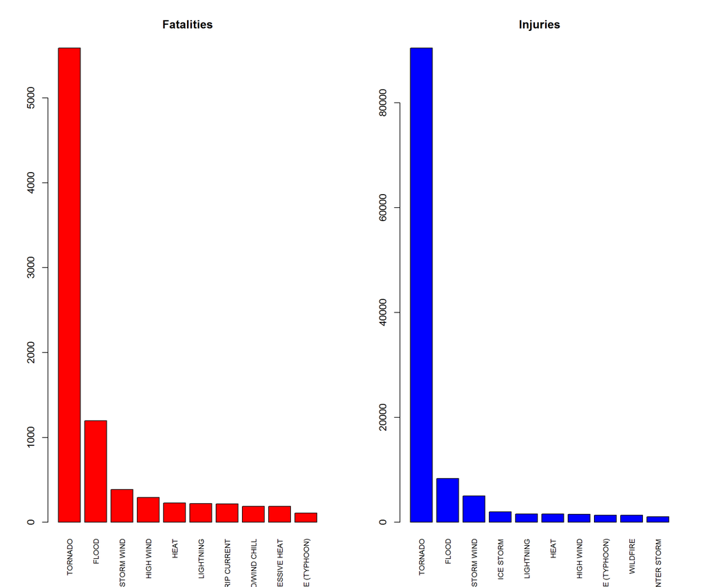

```r
popdmg <- dataexp[,1:5]
popdmg <- group_by(popdmg, EVTYPE)
popdmgsummary <- summarize(popdmg, "INJURIES"=sum(INJURIES), "FATALITIES"=sum(FATALITIES))
topinj <- arrange(popdmgsummary, desc(INJURIES))[1:10,c(1,2)]
topfat <- arrange(popdmgsummary, desc(FATALITIES))[1:10,c(1,3)]

par(mfrow=c(1,2))
barplot(as.vector(topfat$FATALITIES),
        names.arg=(topfat$EVTYPE),
        main="Fatalities",
        col="red",
        cex.names=0.75,
        las=3)
barplot(as.vector(topinj$INJURIES),
        names.arg=(topinj$EVTYPE),
        main="Injuries",
        col="blue",
        cex.names=0.75,
        las=3)
```

```r
kable(topfat)
```

| EVTYPE | FATALITIES |
| --- | --- |
| TORNADO | 5588 |
| FLOOD | 1195 |
| THUNDERSTORM WIND | 386 |
| HIGH WIND | 291 |
| HEAT | 227 |
| LIGHTNING | 222 |
| RIP CURRENT | 216 |
| COLD/WIND CHILL | 189 |
| EXCESSIVE HEAT | 188 |
| HURRICANE (TYPHOON) | 109 |

```r
kable(topinj)
```

| EVTYPE | INJURIES |
| --- | --- |
| TORNADO | 90447 |
| FLOOD | 8365 |
| THUNDERSTORM WIND | 5031 |
| ICE STORM | 2014 |
| LIGHTNING | 1599 |
| HEAT | 1564 |
| HIGH WIND | 1510 |
| HURRICANE (TYPHOON) | 1328 |
| WILDFIRE | 1328 |
| WINTER STORM | 1044 |

We’ve got a pretty good ranking graphed and tabled for harm to the population. Let’s move on to harm in a financial sense.

### US Weather Events Causing Economic Harm

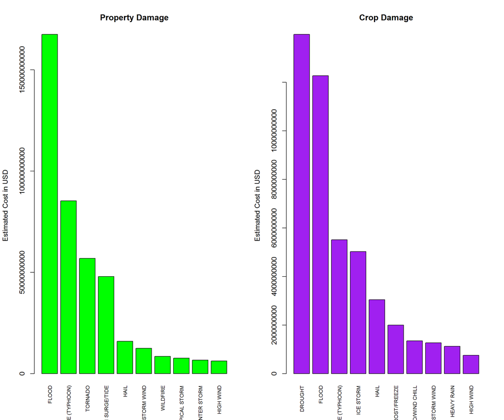

```r
ecdmg <- dataexp[,c(1,3,10,11)]
ecdmg <- group_by(ecdmg, EVTYPE)
ecdmgsummary <- summarize(ecdmg,
                          "PROPERTY"=sum(as.numeric(HISTPROPDMG),na.rm=T),
                          "CROP"=sum(as.numeric(HISTCROPDMG),na.rm=T)
                          )
topprop <- arrange(ecdmgsummary, desc(PROPERTY))[1:10,c(1,2)]
topcrop <- arrange(ecdmgsummary, desc(CROP))[1:10,c(1,3)]

par(mfrow=c(1,2))
barplot(as.vector(topprop$PROPERTY),
        names.arg=(topprop$EVTYPE),
        main="Property Damage",
        ylab="Estimated Cost in USD",
        col="green",
        cex.names=0.75,
        las=3)
barplot(as.vector(topcrop$CROP),
        names.arg=(topcrop$EVTYPE),
        main="Crop Damage",
        ylab="Estimated Cost in USD",
        col="purple",
        cex.names=0.75,
        las=3)
```

```r
kable(topprop)
```

| EVTYPE | PROPERTY |
| --- | --- |
| FLOOD | 167556056020 |
| HURRICANE (TYPHOON) | 85356410010 |
| TORNADO | 56941932230 |
| STORM SURGE/TIDE | 47985809050 |
| HAIL | 15974564220 |
| THUNDERSTORM WIND | 12576573730 |
| WILDFIRE | 8496628500 |
| TROPICAL STORM | 7714390550 |
| WINTER STORM | 6692957250 |
| HIGH WIND | 6261341040 |

```r
kable(topcrop)
```

| EVTYPE | CROP |
| --- | --- |
| DROUGHT | 13972571780 |
| FLOOD | 12270394200 |
| HURRICANE (TYPHOON) | 5516117800 |
| ICE STORM | 5027114300 |
| HAIL | 3046887600 |
| FROST/FREEZE | 1997061000 |
| COLD/WIND CHILL | 1355665500 |
| THUNDERSTORM WIND | 1274203900 |
| HEAVY RAIN | 1130805800 |
| HIGH WIND | 762351950 |

### US Dollar Normalization

```r
# Get the CPI data if it's not present in the data subdirectory
if(!file.exists("./data/CPI.csv")){
  fileurl <- "http://research.stlouisfed.org/fred2/data/CPIAUCSL.csv"
  download.file(fileurl,destfile="./data/CPI.csv",mode='wb')
  rm(fileurl)
  message("CPI data is ready for loading!")
} else {
  message("CPI data already present and ready for loading!")
}
```

```
## CPI data already present and ready for loading!
```

```r
# Load the CPI data
month_cpi <-  read.csv("./data/CPI.csv",
                       header = TRUE)
month_cpi$cpi_year <- year(month_cpi$DATE)
annual_cpi <- month_cpi %>% group_by(cpi_year) %>% summarize(cpi = mean(VALUE))
annual_cpi$adjustment <-
  annual_cpi$cpi/annual_cpi$cpi[annual_cpi$cpi_year == 2015]
cpi <- annual_cpi[c(4:65,69),c(1,3)]
names(cpi) <- c("YEAR","ADJUSTMENT")
cpi$YEAR <- as.character(cpi$YEAR)
```

```r
# Use the factor to adjust the yearly amounts
adjecdmg <- dataexp[,c(1,3,10,11)]
adjecdmg$YEAR <- as.character(adjecdmg$YEAR)
aedo <- group_by(adjecdmg, YEAR, EVTYPE)
adjecdmg <- summarize(aedo, "PROPERTY"=sum(as.numeric(HISTPROPDMG),na.rm=T),
                            "CROP"=sum(as.numeric(HISTCROPDMG),na.rm=T)
                      )
adjecdmg <- left_join(adjecdmg,cpi,by=c("YEAR"="YEAR"))
adjecdmg$PROPERTY <- adjecdmg$PROPERTY * adjecdmg$ADJUSTMENT
adjecdmg$CROP <- adjecdmg$CROP * adjecdmg$ADJUSTMENT
```

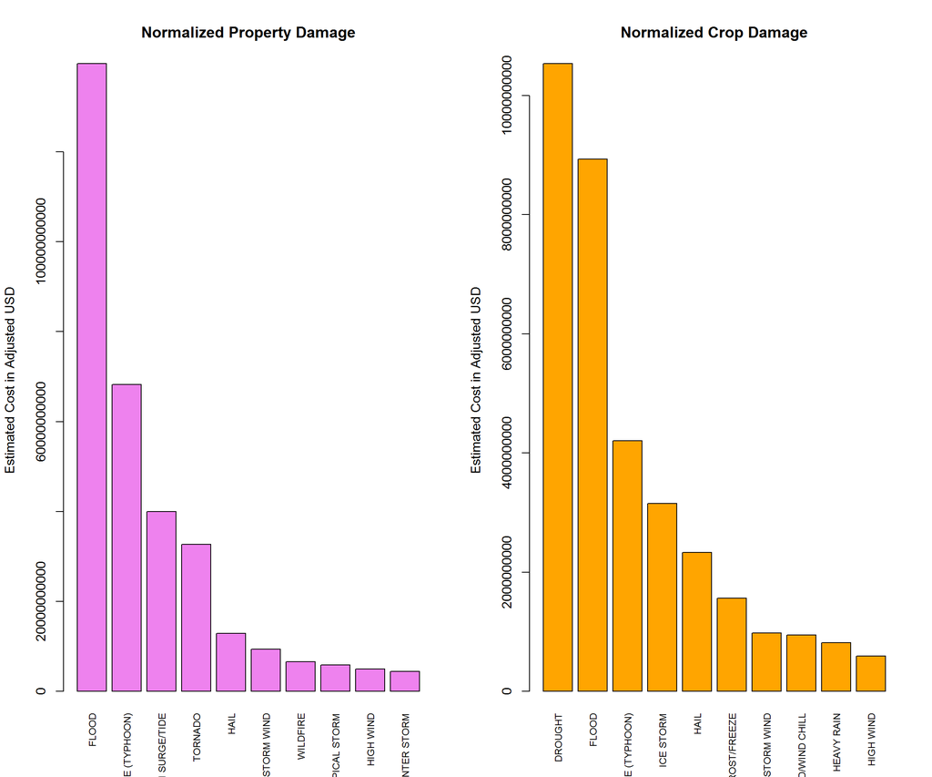

```r
# Reperform analysis
adjecdmg <- group_by(adjecdmg, EVTYPE)
adjecdmgsummary <- summarize(adjecdmg,
                          "PROPERTY"=sum(PROPERTY,na.rm=T),
                          "CROP"=sum(CROP,na.rm=T))
topprop <- arrange(adjecdmgsummary, desc(PROPERTY))[1:10,c(1,2)]
topcrop <- arrange(adjecdmgsummary, desc(CROP))[1:10,c(1,3)]

par(mfrow=c(1,2))
barplot(as.vector(topprop$PROPERTY),
        names.arg=(topprop$EVTYPE),
        main="Normalized Property Damage",
        ylab="Estimated Cost in Adjusted USD",
        col="violet",
        cex.names=0.75,
        las=3)
barplot(as.vector(topcrop$CROP),
        names.arg=(topcrop$EVTYPE),
        main="Normalized Crop Damage",
        ylab="Estimated Cost in Adjusted USD",
        col="orange",
        cex.names=0.75,
        las=3)
```

```r
kable(topprop)
```

| EVTYPE | PROPERTY |
| --- | --- |
| FLOOD | 139623165590 |
| HURRICANE (TYPHOON) | 68213570830 |
| STORM SURGE/TIDE | 39999170072 |
| TORNADO | 32718298486 |
| HAIL | 12870412712 |
| THUNDERSTORM WIND | 9349394425 |
| WILDFIRE | 6626279362 |
| TROPICAL STORM | 5859858601 |
| HIGH WIND | 4950011670 |
| WINTER STORM | 4466066606 |

```r
kable(topcrop)
```

| EVTYPE | CROP |
| --- | --- |
| DROUGHT | 10535171374 |
| FLOOD | 8934996334 |
| HURRICANE (TYPHOON) | 4207313128 |
| ICE STORM | 3154233353 |
| HAIL | 2333594359 |
| FROST/FREEZE | 1565437873 |
| THUNDERSTORM WIND | 975921898 |
| COLD/WIND CHILL | 941845088 |
| HEAVY RAIN | 815740231 |
| HIGH WIND | 594660093 |

## Results

1. Across the United States, which types of events (as indicated in the EVTYPE variable) are most harmful with respect to population health?

As born out in the analysis above, Tornados, Floods, and Storm Winds respectively account for the most Fatalities and Injuries.

2. Across the United States, which types of events have the greatest economic consequences?

Using raw historical dollars, Floods, Hurricanes, and Tornados caused the most property damage, respectively. Using the same historical dollars, Droughts, Floods, and Hurricanes caused the most crop damage, respectively.